# Ayudantía 6

Diego Bernal Soto

2025-04-29

# Enunciado I

Se encarga de realizar el aprovisionamiento para el catering de la business class en los aviones **Lasan**. Es por ello que, como equipo, deciden ir a visitar a los posibles candidatos para cerrar un contrato por un año en los destinos de Los Ángeles y Madrid.

Para este estudio, utilizaron a la célula de **Shared Services** para que realizara un análisis histórico de los vinos tintos consumidos por los pasajeros en años anteriores, catalogándolos con una escala métrica que va del 0 al 8, siendo este último catalogado como de excelencia.

$$\begin{aligned}
Y &= \text{Calidad de Vino} \\
X_1 &= \text{Grados de alcohol contenidos} \\
X_2 &= \text{Volatilidad del ácido (g/100 ml)} \\
X_3 &= \text{Ácido cítrico (en porcentaje)} \\
X_4 &= \text{pH del vino}
\end{aligned}$$

### Resultados Modelos Auxiliares

| Mod | Variables | Adjusted R-squared |
| --- | --- | --- |
| 1 | X1 | 0.226 |
| 2 | X1, X3 | 0.316 |
| 3 | X2, X3 | 0.256 |
| 4 | X1, X2, X4 | 0.321 |
| 5 | X1, X2, X3, X4 | 0.322 |

Por lo que se le pide que apoye con la inferencia al equipo, para esto elaboraron las siguientes preguntas:

- ¿Es significativo el aporte de la variable $X_3$ ?. Utilice un nivel de significancia de 0.05.
- ¿Es significativo el aporte conjunto de $X_1$ y $X_4$.Utilice un nivel de significancia de 0.05.
- Se corrio una regresion auxiliar entre los residuales del modelo 1 y todas las variables Xs presentes en el modelo 5. Utilizando el estadistico adecuado pruebe que es posible eliminar las variables $X_2$, $X_3$ y $X_4$.

### Resultados Pregunta N°3

| Estadísticas de la regresión | Valores |
| --- | --- |
| Coeficiente de correlación múltiple | 0.23488 |
| Coeficiente de determinación $R^2$ | 0.05517 |
| $R^2$ ajustado | 0.05279 |
| Error típico | 0.69172 |
| Observaciones | 1593 |

**Tabla 1.** Regresión auxiliar

## Enunciado II

En base a la base de datos anterior plantee el modelo para predecir la variable dependiente calidad del vino en razon de las demas variables y realice los siguientes requerimientos.

- Revise el modelo anterior y identifique si existen outliers en la muestra, grafique y realice los test de hipotesis correspondiente.
- Realice el calculo de las distancias de Cook para ver si un punto es influyente o no, observe el grafico.
- Realice una prueba de independencia de los errores con un nivel de significancia de 0.05.
- Identifique si hay multicolinealidad entre los regresores de dos formas distintas.

Ejercicio N°1

```r
#Required libraries
library(corrplot)
library(mixlm)
library(readxl)
library(stargazer)
library(paqueteadp)
library(remotes)
library(ggcorrplot)
library(tidyverse)
library(cowplot)
library(caret)
library(glmnet)
library(car)
library(gghighlight)
library(rlang)
library(tidyverse)
library(tidymodels)
library(schrute)
library(lubridate)
library(knitr)
library(ggsci)
```

```r
df_wine <- read_excel("./Ayudantía_7.xlsx",
                             sheet = "Datos")
glimpse(df_wine)
```

```
## Rows: 1,593
## Columns: 12
## $ fixed_acidity        <dbl> 7.4, 7.8, 7.8, 11.2, 7.4, 7.4, 7.9, 7.3, 7.8, 7.5…
## $ volatile_acidity     <dbl> 0.700, 0.880, 0.760, 0.280, 0.700, 0.660, 0.600, …
## $ citric_acid          <dbl> 0.00, 0.00, 0.04, 0.56, 0.00, 0.00, 0.06, 0.00, 0…
## $ residual_sugar       <dbl> 1.9, 2.6, 2.3, 1.9, 1.9, 1.8, 1.6, 1.2, 2.0, 6.1,…
## $ chlorides            <dbl> 0.076, 0.098, 0.092, 0.075, 0.076, 0.075, 0.069, …
## $ free_sulfur_dioxide  <dbl> 11, 25, 15, 17, 11, 13, 15, 15, 9, 17, 15, 17, 16…
## $ total_sulfur_dioxide <dbl> 34, 67, 54, 60, 34, 40, 59, 21, 18, 102, 65, 102,…
## $ density              <dbl> 0.9978, 0.9968, 0.9970, 0.9980, 0.9978, 0.9978, 0…
## $ pH                   <dbl> 3.51, 3.20, 3.26, 3.16, 3.51, 3.51, 3.30, 3.39, 3…
## $ sulphates            <dbl> 0.56, 0.68, 0.65, 0.58, 0.56, 0.56, 0.46, 0.47, 0…
## $ alcohol              <dbl> 9.4, 9.8, 9.8, 9.8, 9.4, 9.4, 9.4, 10.0, 9.5, 10.…
## $ quality              <dbl> 5, 5, 5, 6, 5, 5, 5, 7, 7, 5, 5, 5, 5, 5, 5, 5, 7…
```

```r
mod1 <- lm(quality~ alcohol,data=df_wine)

mod2 <- lm(quality~alcohol+volatile_acidity,data=df_wine)

mod3 <- lm(quality~alcohol+ citric_acid,data = df_wine)
mod4 <- lm(quality~ alcohol+volatile_acidity+pH,data=df_wine)

mod5 <- lm(quality ~ alcohol+volatile_acidity+pH+citric_acid,data = df_wine)
```

```r
stargazer(mod1, mod2, mod3, mod4, mod5,
          title = "Modelo",
          align = TRUE,
          type = "html")
```

**Modelo**

|  | *Dependent variable:* |  |  |  |  |
| --- | --- | --- | --- | --- | --- |
|  | quality |  |  |  |  |
|  | (1) | (2) | (3) | (4) | (5) |
| alcohol | 0.361*** | 0.361*** | 0.346*** | 0.386*** | 0.364*** |
|  | (0.017) | (0.017) | (0.017) | (0.017) | (0.017) |
| volatile_acidity |  | -0.001*** |  | -0.001*** | -0.001*** |
|  |  | (0.0003) |  | (0.0003) | (0.0003) |
| citric_acid |  |  | 0.733*** |  | 0.514*** |
|  |  |  | (0.090) |  | (0.110) |
| pH |  |  |  | -0.841*** | -0.458*** |
|  |  |  |  | (0.116) | (0.141) |
| Constant | 1.867*** | 1.873*** | 1.825*** | 4.398*** | 3.220*** |
|  | (0.175) | (0.175) | (0.172) | (0.387) | (0.460) |
| Observations | 1,593 | 1,593 | 1,593 | 1,593 | 1,593 |
| R<sup>2</sup> | 0.226 | 0.234 | 0.257 | 0.259 | 0.269 |
| Adjusted R<sup>2</sup> | 0.226 | 0.233 | 0.256 | 0.258 | 0.267 |
| Residual Std. Error | 0.711 (df = 1591) | 0.708 (df = 1590) | 0.697 (df = 1590) | 0.696 (df = 1589) | 0.692 (df = 1588) |
| F Statistic | 465.769*** (df = 1; 1591) | 243.457*** (df = 2; 1590) | 275.425*** (df = 2; 1590) | 185.225*** (df = 3; 1589) | 146.191*** (df = 4; 1588) |
| *Note:* | p<0.1; p<0.05; p<0.01 |  |  |  |  |

```r
mod6 <- lm(quality~ fixed_acidity+volatile_acidity+citric_acid+residual_sugar+chlorides+free_sulfur_dioxide+total_sulfur_dioxide+
             density+pH+sulphates+alcohol,data=df_wine)
```

```r
outlierTest(mod6,cutoff=Inf, n.max=15)
```

```
##       rstudent unadjusted p-value Bonferroni p
## 833  -4.045438         5.4746e-05      0.08721
## 900  -3.802711         1.4857e-04      0.23667
## 653  -3.633390         2.8867e-04      0.45985
## 1474 -3.605933         3.2070e-04      0.51088
## 1501 -3.537404         4.1576e-04      0.66231
## 1466 -3.508991         4.6242e-04      0.73664
## 1277 -3.487538         5.0085e-04      0.79785
## 460  -3.439109         5.9880e-04      0.95389
## 1300 -3.355632         8.1061e-04           NA
## 152  -3.189477         1.4533e-03           NA
## 1240 -2.946969         3.2561e-03           NA
## 46   -2.908090         3.6872e-03           NA
## 441   2.897425         3.8142e-03           NA
## 518  -2.895812         3.8338e-03           NA
## 496   2.879563         4.0359e-03           NA
```

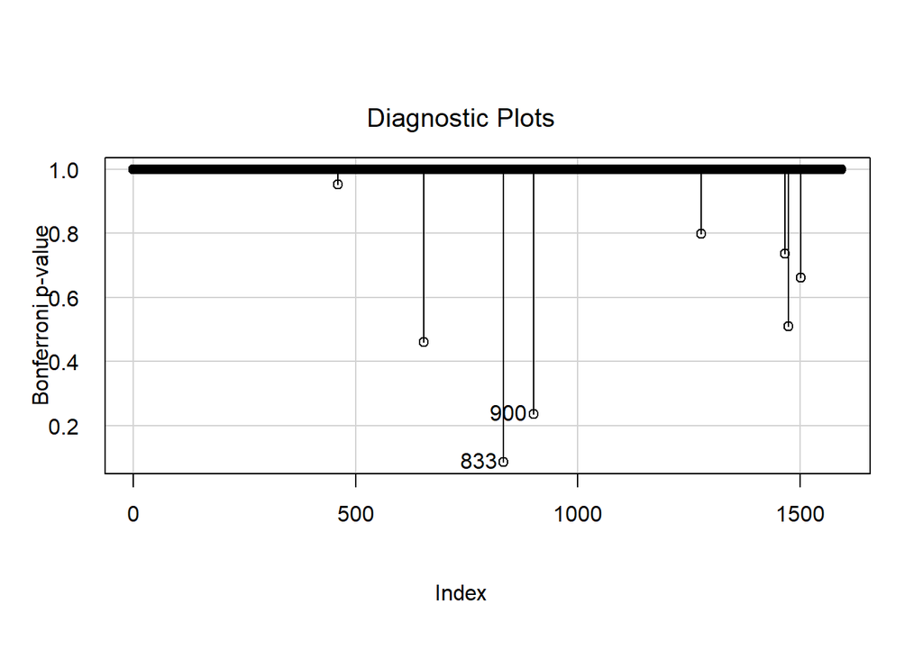

```r
influenceIndexPlot(mod6, vars="Bonf", las=1,id.col=palette()[3])
```

Prueba con algorimto backward

```r
mod7 <- mixlm::backward(mod6, alpha=0.04)
```

Backward elimination, alpha-to-remove: 0.04

Full model: quality ~ fixed_acidity + volatile_acidity + citric_acid + residual_sugar + chlorides + free_sulfur_dioxide + total_sulfur_dioxide + density + pH + sulphates + alcohol

[output not shown]

```r
stargazer(mod6,mod7,title = "Ayud_6", align = TRUE,
          type = "html")
```

**Ayud**

|  | *Dependent variable:* |  |
| --- | --- | --- |
|  | quality |  |
|  | (1) | (2) |
| fixed_acidity | -0.021 |  |
|  | (0.017) |  |
| volatile_acidity | -0.001*** | -0.001*** |
|  | (0.0003) | (0.0003) |
| citric_acid | 0.513*** | 0.426*** |
|  | (0.128) | (0.109) |
| residual_sugar | 0.006 |  |
|  | (0.013) |  |
| chlorides | -2.897*** | -2.785*** |
|  | (0.411) | (0.401) |
| free_sulfur_dioxide | 0.008*** | 0.008*** |
|  | (0.002) | (0.002) |
| total_sulfur_dioxide | -0.005*** | -0.005*** |
|  | (0.001) | (0.001) |
| density | -0.00000 |  |
|  | (0.00000) |  |
| pH | -0.649*** | -0.528*** |
|  | (0.160) | (0.137) |
| sulphates | 1.066*** | 1.058*** |
|  | (0.111) | (0.111) |
| alcohol | 0.297*** | 0.301*** |
|  | (0.018) | (0.018) |
| Constant | 4.367*** | 3.765*** |
|  | (0.633) | (0.463) |
| Observations | 1,593 | 1,593 |
| R<sup>2</sup> | 0.333 | 0.331 |
| Adjusted R<sup>2</sup> | 0.328 | 0.328 |
| Residual Std. Error | 0.662 (df = 1581) | 0.663 (df = 1584) |
| F Statistic | 71.661*** (df = 11; 1581) | 98.079*** (df = 8; 1584) |
| *Note:* | p<0.1; p<0.05; p<0.01 |  |

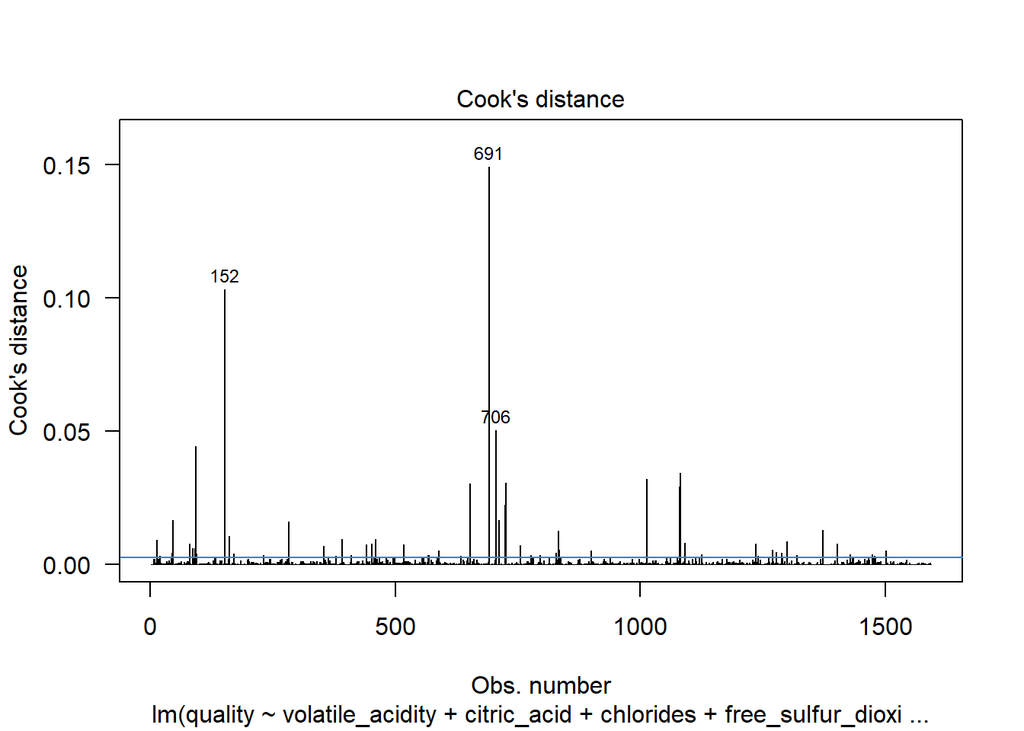

```r
cutoff <- 4 / (1593-9-2)  # Cota
plot(mod7, which=4, cook.levels=cutoff, las=1)
abline(h=cutoff, col="dodgerblue2")
```

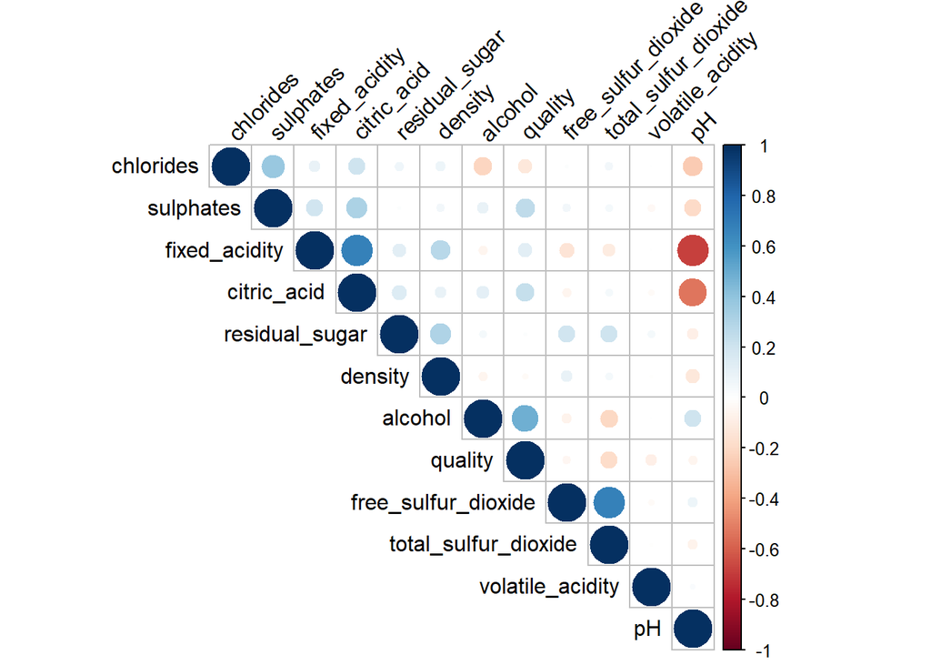

```r
df_wine %>% cor(method="pearson") %>% round(digits=2) -> mat_cor

corrplot(mat_cor, type="upper", order="hclust", tl.col="black", tl.srt=45)
```